# IS451 Classification Tree Tutorial

## Demo: Universal Bank

Universal Bank is a relatively young bank that is growing rapidly in terms of overall customer acquisition. The majority of these customers are liability customers with varying sizes of relationship with the bank. The customer base of asset customers is quite small, and the bank is interested in growing this base to bring in more loan busness. In particular, it wants to explore ways of converting its liability (deposit) customers to personal loan customers.

A campaign the bank ran for liability customers showed a healthy conversion rate of over 9% successes. This has encouraged the retail marketing department to devise smarter campaigns with better target marketing. The goal of our analysis is to model the previous campaign’s customer behavior to analyze what combination of factors make a customer more likely to accept a personal loan.

The predictors include demographic info (Age, Income), and the customer’s relationship with the bank (mortgage, securities, account, etc.)

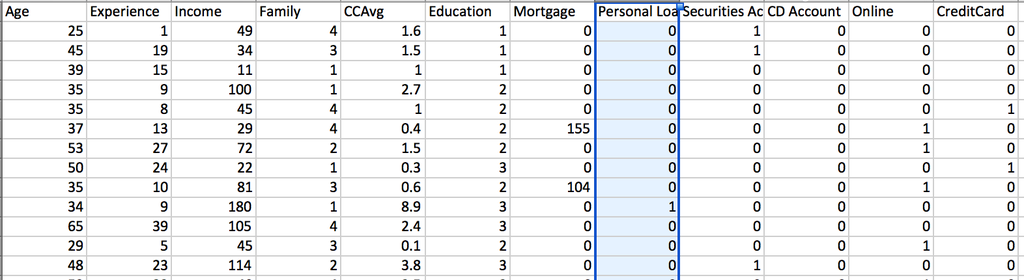

### Step 1: read data

```r
# load data
bank.df <- read.csv("UniversalBank.csv", stringsAsFactors = TRUE)
```

### Step 2: Partition the records into `60%` training vs. `40%` validation with the seed set to 11.

To create a train and validation set, we are going to split randomly this data set into 60% training set and 40% validation set.

We have `nrow(bank.df)` data points in total. We find the observations we want to include in the training set by randomly sample 60% $\times$ `nrow(bank.df)` indexes out of `nrow(bank.df)` observations.

Random seed is set using `set.seed(11)` to control reproducibility so that every time you run the random partitioning, it will give you the same result.

```r
set.seed(11)  # set seed for reproducing the partition
# Random sample indexes
train.index <- sample(1:nrow(bank.df), nrow(bank.df)*0.6)
```

After we get the training indexes from random sample, we can build the training and validation set.

```r
# Build training and validation set by indexing
train.df <- bank.df[train.index, ]
valid.df <- bank.df[-train.index, ]
```

### Step 3: Build classification tree from training data.

Overfitting can definitely happen if your tree is too big. We can set criteria to stop tree growth.

In order to use the CART model in R, we need to install and use the `rpart` library.

```r
# if not installed, run:
# install.packages("rpart")
library(rpart)
```

If we want to visualize the tree after the model fitting, we need to further install and use the `rpart.plot` library.

```r
# if not installed, run:
# install.packages("rpart.plot")
library(rpart.plot)
```

To grow a tree, use **rpart**(formula, **data=**, **method=**,**control=**) where

- formula : is a formula in R with `~` format
- data= : specifies the data frame
- method= :
  - **“class”** for a classification tree
  - **“anova”** for a regression tree
- control= : optional parameters for controlling tree growth

#### Default classification tree

We first generate the default tree using `rpart()` function if you do not specify any controllable values.

`Personal.Loan ~ .` is a formula, meaning that `Personal.Loan` is our target, and all the other variables in the data frame (`train.df`) are predictors.

```r
default.ct <- rpart(Personal.Loan ~ ., data = train.df, method = "class")
```

`default.ct` holds the fitted classification tree. We can visualize the tree structure by calling the `rpart.plot` function. You can control plotting parameters such as type, color, shape, and information displayed (which and where). See more information using `?rpart.plot`.

We can change different plotting styles and add different information in the display.

- extra: Display extra information at the nodes (possible values 1 - 11).

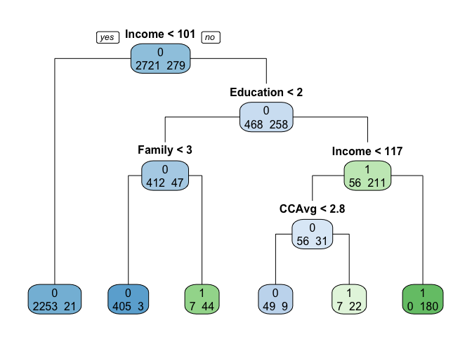

```r
rpart.plot(default.ct, type = 1, extra = 1)
```

#### Generate other trees

We can control some of the parameters to vary the `rpart` fit. For example,

- minbucket: the minimum number of observations in any terminal leaf node
- maxdepth: the maximum depth of any node of the final tree, with the root node counted as depth 0.

For more information, see `?rpart.control`.

You can play around with different combination of control parameters and generate various trees to find the best one in your performance evaluation or meet your need!

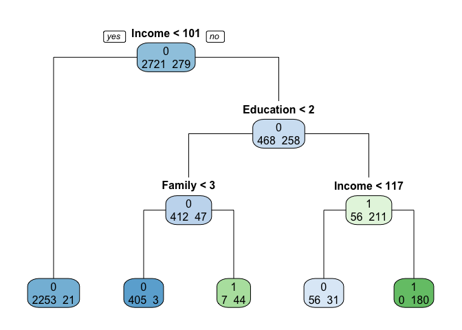

```r
my.ct <- rpart(Personal.Loan ~ ., data = train.df, method = "class", control = rpart.control(maxdepth =  3, minbucket =  30))
rpart.plot(my.ct,  type=1, extra = 1)
```

### Step 4: Interpret the fitted tree

CART provides easily understandable classification rules (if the tree are not too large). Each leaf node is equivalent to a classification rule. For example, in `my.ct`, the right-most leaf node gives us the rule:

**IF** (Income >= 117) **AND** (Education >= 2) **THEN** (Class = 1).

Also, CART gives us the result of **important features** simultaneously, e.g. `Income`, `Education` and `Family`, are more important factors in deciding whether the customer will accept a personal loan. This can serve as the basis for the design of a new campaign.

### Step 5:Performance Evaluation

#### Make predictions for the validation data

Use `predict` function to make predictions of any data set. Since we want the predicted labels to be class memberships, we need to specify `type = "class"` in the `predict` function. Otherwise, it gives you a probability of belonging to each class.

We are using the **default tree** in the remaining part.

```r
# classify records in the validation data.
# set argument type = "class" in predict() to generate predicted class membership.
# Otherwise, a probability of belonging to each class
default.ct.point.pred <- predict(default.ct, valid.df, type = "class")
```

**NOTE:** here `valid.df` can be changed to `train.df` or any data frame representing new customers to find the prediction for training data, or new data.

#### Find classification accuracy

We need to use library `caret` and call the `confusionMatrix` function to compute the confusion matrix. Confusion matrix can be computed for any data set as long as you have the predicted values and the true values.

The first argument to the `confusionMatrix` function is the predicted values. The second argument is the true labels. Since confusion matrix is a measure of classification method (whose target is categorical), both the predicted value and the true value need to be **factors**.

```r
# install.packages("caret", dependencies = TRUE)
library(caret)
# generate confusion matrix for validation data
confusionMatrix(default.ct.point.pred, factor(valid.df$Personal.Loan))
```

```
## Confusion Matrix and Statistics
##
##           Reference
## Prediction    0    1
##          0 1781   27
##          1   18  174
##
##                Accuracy : 0.9775
##                  95% CI : (0.97, 0.9835)
##     No Information Rate : 0.8995
##     P-Value [Acc > NIR] : <2e-16
##
##                   Kappa : 0.873
##
##  Mcnemar's Test P-Value : 0.233
##
##             Sensitivity : 0.9900
##             Specificity : 0.8657
##          Pos Pred Value : 0.9851
##          Neg Pred Value : 0.9063
##              Prevalence : 0.8995
##          Detection Rate : 0.8905
##    Detection Prevalence : 0.9040
##       Balanced Accuracy : 0.9278
##
##        'Positive' Class : 0
##
```

In the output confusion matrix, `Reference` means actual labels, `Prediction` means predicted labels. The validation accuracy for the default tree is 0.9775.